# Missouri Earthquate Data Set

## Introduction

This notebook details the creation of a data set of earthquakes in Missouri.

## Dependencies

The following packages are required for this notebook:

```r
library(dplyr)        # data wrangling
library(ggplot2)      # plotting
library(rio)          # data import
library(skimr)        # descriptive statistics
library(tigris)       # download census shapefiles
```

## Obtaining Raw Data

The data were obtained from the [USGS Earthquake Catalog](https://earthquake.usgs.gov/earthquakes/search/). The search parameters used were for earthquakes of at least a magnitude of `2.0` between `1973-01-01 00:00:00` and `2017-12-31 23:59:59`. A custom rectanlge around Missouri was drawn that covered the following coordinates - [`35.909, 40.699`] Latitude and [`-95.845, -88.989`] Longitude. These were output as `CSV` data and ordered with the oldest event first. They were saved to the file `earthquakes.csv` available in this repository.

```r
quakes <- import("earthquakes.csv")
```

## Initial Exploration of the Data

Magnitude of earthquakes is measured using the [Richter scale](https://en.wikipedia.org/wiki/Richter_magnitude_scale). Earthquakes between 2 and 3.9 are considered minor with damage rarely reported. Earthquakes between 4 and 4.9 are considered light, with some minor damage (like objects falling inside buildings). Earthquakes with magnitudes greater than 5 cause increasingly greater amounts of damage. A lesser understood point is that the Richter scale is logrithmic and not linear, meaning that the power of an earthquake increases dramatically with each whole number increase on the scale.

We’ll start by using `skimr` to create a quick summary of the magnitude variable:

```r
skim(quakes, mag)
```

```
Skim summary statistics
 n obs: 1845
 n variables: 22

Variable type: numeric
 variable missing complete    n mean   sd p0 p25 median p75 p100     hist
      mag       0     1845 1845 2.37 0.39  2 2.1    2.3 2.5  4.8 ▇▃▁▁▁▁▁▁
```

We can get a better summary of the distribution of earthquake magnitudes by creating a histogram of their magnitude:

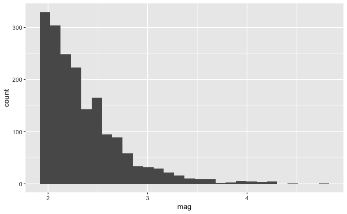

```r
ggplot(data = quakes, mapping = aes(mag)) +
  geom_histogram(bins = 28)
```

We can also look at earthquake frequency over time by creating a year variable and then making another histogram. The year variable is made by extracting the first four characters of the `time` variable, which are always the year in these data.

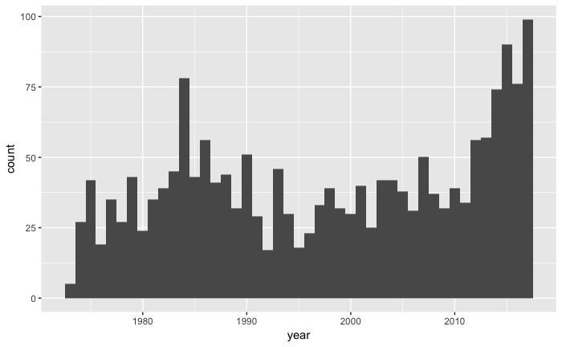

```r
quakes <- mutate(quakes, year = as.integer(substr(time, 1, 4)))

ggplot(quakes, mapping = aes(year)) +
  geom_histogram(bins = 45)
```

There does seem to be some patterning, with a peak in the mid-1980s and a recent increase after 2010.

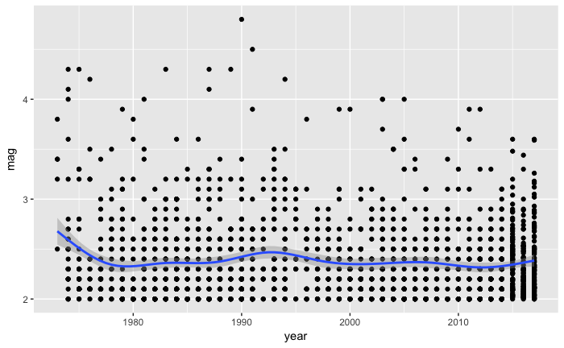

```r
ggplot(quakes, mapping = aes(x = year, y = mag)) +
  geom_point() +
  geom_smooth()
```

There is no real increase or decrease in the typical magnitude of earthquakes over each year in the data set.

## Mapping Earthquakes

We’ll start by downloading a shapefile of all states using the `tigris` package, and then convert it to a simple feature object. What we really need is just the Missouri state boundary, so we’ll extract that from the larger data set.

```r
us <- states(year = 2015)
us <- st_as_sf(us)
mo <- filter(us, GEOID == "29")
rm(us)
```

We can check that the conversion worked by making a simple map of Missouri using the `geom_sf()` geom from `ggplot2`. *This geom is currently only available from the development version.*

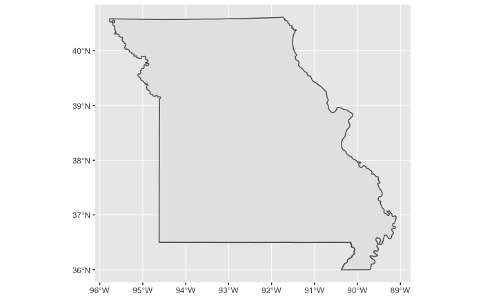

```r
ggplot() +
  geom_sf(data = mo)
```